# ecRBI+, a Study in Clutch Hitting

Sam Messer

12/5/17

*Source file* ⇒ project_final.Rmd

### **Background**

20 years ago, you’d be hard pressed to find any sort of data being used in the sports world. The generally accepted knowledge was that those who had played the game knew best how it worked, and their expertise was the only thing necessary for a team to be competitive. That all changed in the early 2000’s when a baseball executive by the name of Billy Beane began to use numbers to build his team. His circumvention of the common knowledge allowed him to gain a massive competitive edge at a fraction of the price.

I’m speaking, of course, about the story behind “Moneyball,” a book and feature film that is often looked at as the beginning of modern sports analytics. The so-called “Data Revolution” in sports is at an all-time high, and it’s only continuing to grow. Front offices of major league teams across the country spend a large amount of time and money trying to generate any sort of competitive edge.

One way that teams are looking to create a competitive edge is by developing new advanced metrics to measure players. If the team can distinguish one hitter as a safer choice than another in a certain situation where another team may have made a different choice, the team who can distinguish will usually come out on top.

My hope with this project is to create an advanced metric and see how baseball’s “best” hitters stack up. This new stat will be called *ecRBI+*, an index of expected contact RBI. I’ll explain what this means after I calculate it.

All data comes from retrosheet, a free online database that contains play-by-play files for most games played in the past 90 years.

### **Getting the Data**

Retrosheet is an invaluable resource for everyone interested in baseball statistics, but it’s data isn’t particularly easy to work with. Here, I use a function from Max Marchi and Jim Albert’s book, “Analyzing Baseball Data with R.” It takes the event files from retrosheet and generates two .csv files, one with the play-by-play record, and one with team rosters for the season. For ease, I have already run through this code for the necessary seasons so that you don’t have to worry about setting up directories for the function to work as intended.

```
parse.retrosheet.pbp = function(season){
  # download, unzip, append retrosheet data
  # assume current directory has a folder download.folder
  # download.folder has two subfolders unzipped and zipped
  # program cwevent.exe is in unzipped folder (for windows)

  download.retrosheet <- function(season){
    # get zip file from retrosheet website
    download.file(
      url=paste("http://www.retrosheet.org/events/", season, "eve.zip", sep="")
      , destfile=paste("download.folder", "/zipped/", season, "eve.zip", sep="")
    )
  }
  unzip.retrosheet <- function(season){
    #unzip retrosheet files
    unzip(paste("download.folder", "/zipped/", season, "eve.zip", sep=""),
          exdir=paste("download.folder", "/unzipped", sep=""))
  }
  create.csv.file=function(year){
    # http://chadwick.sourceforge.net/doc/cwevent.html#cwtools-cwevent
    # shell("cwevent -y 2000 2000TOR.EVA > 2000TOR.bev")
    wd = getwd()
    setwd("download.folder/unzipped")
    shell(paste(paste("cwevent -y", year, "-f 0-96"),
                paste(year,"*.EV*",sep=""),
                paste("> all", year, ".csv", sep="")))
    setwd(wd)
  }
  create.csv.roster = function(year){
    # creates a csv file of the rosters
    filenames <- list.files(path = "download.folder/unzipped/")
    filenames.roster =
      subset(filenames, substr(filenames, 4, 11)==paste(year,".ROS",sep=""))
    read.csv2 = function(file)
      read.csv(paste("download.folder/unzipped/", file, sep=""),header=FALSE)
    R = do.call("rbind", lapply(filenames.roster, read.csv2))
    names(R)[1:6] = c("Player.ID", "Last.Name", "First.Name",
                      "Bats", "Pitches", "Team")
    wd = getwd()
    setwd("download.folder/unzipped")
    write.csv(R, file=paste("roster", year, ".csv", sep=""))
    setwd(wd)
  }
  cleanup = function(){
    # removes retrosheet files not needed
    wd = getwd()
    setwd("download.folder/unzipped")
    shell("del *.EVN")
    shell("del *.EVA")
    shell("del *.ROS")
    shell("del TEAM*")
    setwd(wd)
  }
  download.retrosheet(season)
  unzip.retrosheet(season)
  create.csv.file(season)
  create.csv.roster(season)
  cleanup()
}
```

### **Cleaning the Data**

Here I’m going to define a function that will clean the retrosheet data down to only what I need.

```r
retrosheet.clean <- function(chadwick_table) {
  Clean_events <- chadwick_table %>%
    select(V5, V11, V27, V28, V29, V30, V44) %>%
    #For this stat, we only care about the on base situation (outs and runner
    #locations) and what actually happened
    rename(outs = "V5", batter = "V11", b1 = "V27", b2 = "V28", b3 = "V29", event = "V30", rbi_play = "V44") %>%
    #We don't care who is on base, just that there is someone there, so we
    #replace batter ID with a simple base flag
    mutate(b1 = ifelse(b1=="", 0, 1),
           b2 = ifelse(b2=="", 0, 1),
           b3 = ifelse(b3=="", 0, 1),
           #Define on base situation: each combination of (1,2,3) on base and
           #(0,1,2) outs is a different situation
           situation = case_when(
             b1==0 & b2==0 & b3==0 & outs==0 ~ 1,
             b1==0 & b2==0 & b3==0 & outs==1 ~ 2,
             b1==0 & b2==0 & b3==0 & outs==2 ~ 3,
             b1==1 & b2==0 & b3==0 & outs==0 ~ 4,
             b1==1 & b2==0 & b3==0 & outs==1 ~ 5,
             b1==1 & b2==0 & b3==0 & outs==2 ~ 6,
             b1==0 & b2==1 & b3==0 & outs==0 ~ 7,
             b1==0 & b2==1 & b3==0 & outs==1 ~ 8,
             b1==0 & b2==1 & b3==0 & outs==2 ~ 9,
             b1==1 & b2==1 & b3==0 & outs==0 ~ 10,
             b1==1 & b2==1 & b3==0 & outs==1 ~ 11,
             b1==1 & b2==1 & b3==0 & outs==2 ~ 12,
             b1==0 & b2==0 & b3==1 & outs==0 ~ 13,
             b1==0 & b2==0 & b3==1 & outs==1 ~ 14,
             b1==0 & b2==0 & b3==1 & outs==2 ~ 15,
             b1==1 & b2==0 & b3==1 & outs==0 ~ 16,
             b1==1 & b2==0 & b3==1 & outs==1 ~ 17,
             b1==1 & b2==0 & b3==1 & outs==2 ~ 18,
             b1==0 & b2==1 & b3==1 & outs==0 ~ 19,
             b1==0 & b2==1 & b3==1 & outs==1 ~ 20,
             b1==0 & b2==1 & b3==1 & outs==2 ~ 21,
             b1==1 & b2==1 & b3==1 & outs==0 ~ 22,
             b1==1 & b2==1 & b3==1 & outs==1 ~ 23,
             b1==1 & b2==1 & b3==1 & outs==2 ~ 24),
           #A contact RBI is one where the hitter drives in a runner other than himself. If
           #there is a homer on the play, 1 RBI is subtracted from the cRBI.
           cRBI = ifelse(grepl("HR", event), rbi_play - 1, rbi_play),
           #We want to remove all intentional walks except when the bases are loaded because
           #an intentional walk gives the batter no chance to hit the ball, and we don't
           #want to penalize those who get intentional walks a lot.
           ibb_flag = ifelse(grepl("IW", event), 1, 0)) %>%
    filter(ibb_flag == 0 | (ibb_flag == 1 & situation >= 22)) %>%
    select(batter, situation, cRBI)
  return(Clean_events)
}
```

### **Creating the Run Expectancy Matrix**

Now I’m going to read in the data from the 2017 season and create a run expectancy matrix. For each situation noted above, I will take the total contact RBI and divide it by the total number of times that situation occurred. With enough data, this will serve effectively as a long-run average (an expected value) for each situation. So our run expectancy matrix will include the situation and the expected number of contact RBI in that situation.

```r
Events_2017 <- read.csv("all2017.csv",header=FALSE)

Clean_2017 <- retrosheet.clean(Events_2017)
Run_matrix <- Clean_2017 %>%
  #This filter is here to catch any situations where there is an event that doesn't end the plate appearance
  #This includes: stolen bases, picked off runners, etc.
  filter(batter != lead(batter)) %>%
  group_by(situation) %>%
  summarise(n_situation=n(), total=sum(cRBI)) %>%
  mutate(ecRBI = (total / n_situation))
```

### **Calculating the Stat for Every Batter in the League**

The last step from here is to combine the batter data with the rosters to get numbers for every batter in the league.

```r
#Player_RBI takes the cleaned data from this season and joins it with the run
#expectancy matrix and adds it up to get Season long numbers for all batters.
#I'm also keeping track of PA here so I can filter it later
Player_RBI <- Clean_2017 %>%
  left_join(Run_matrix, by="situation") %>%
  select(batter, cRBI, ecRBI) %>%
  group_by(batter) %>%
  summarise(pa = n(), total_cRBI = sum(cRBI), total_ecRBI = sum(ecRBI))

#The next two data tables serve to add more useful information.
#Batter ID's are replaced by batter names, and we get the position for position by position comparison
Players_2017 <- read.csv("roster2017.csv")

Players_with_numbers <- Player_RBI %>%
  left_join(Players_2017, by=c("batter"="Player.ID")) %>%
  select(batter, total_cRBI, total_ecRBI, pa, Last.Name, First.Name, V7) %>%
  rename(position = "V7") %>%
  #Filter out batters with fewer than 100 PA. This is an arbitrary number, but it removes a lot of irrelevant data
  filter(pa >= 100)
#Some players were traded in the middle of the season, and thus have two entries in the roster csv. Here, I'm
#just removing those duplicates
Unique_players <- unique(Players_with_numbers[,])

#Finally, I create the index here and keep the variables that will be of interest for the visualization
Final <- Unique_players %>%
  mutate(ecRBI_plus = 100 + (((total_cRBI - total_ecRBI)/total_ecRBI)*100),
         name = paste(First.Name, "\n", Last.Name)) %>%
  select(name, ecRBI_plus, pa, total_ecRBI, total_cRBI, position) %>%
  arrange(desc(ecRBI_plus))
```

### **The Stat**

It’s now time to explain what this stat actually is, if you haven’t gathered it by now. Basically, ecRBI+ is an index of performance in contact RBI as compared to what is expected of the player.

- The index (as designated by the + at the end) scales the batter’s performance to nice round numbers that are easy for us to read. A value of 100 means that the batter is performing at the league average. Greater than 100 means that the batter is performing above league average, and less than 100 means that the batter is performing below league average. The plot below shows all of the batters who recorded at least 100 plate appearances in 2017, along with a line indicating league average. If the batter falls above the line, he is performing better than average, if he falls below, the opposite is true. Above and below the line are colored for clarity.

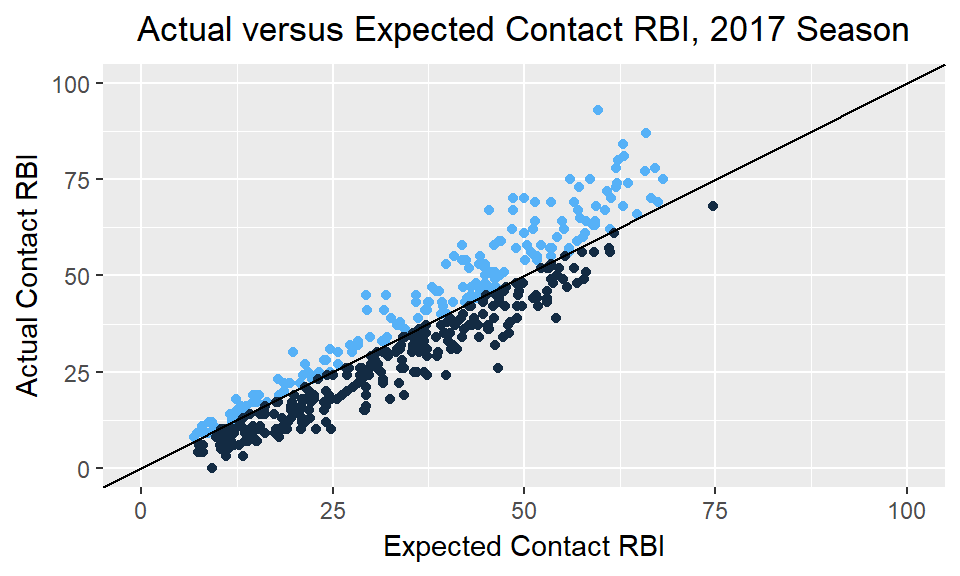

```r
Final %>%
  mutate(good_flag = ifelse(ecRBI_plus >= 100, 1, 0)) %>%
  ggplot(aes(x=total_ecRBI, y=total_cRBI, color = good_flag)) +
    geom_point() + geom_abline(slope = 1, intercept = 0) +
    labs(x="Expected Contact RBI",
         y="Actual Contact RBI",
         title = "Actual versus Expected Contact RBI, 2017 Season") +
  xlim(0, 100) + ylim(0, 100) +
  theme(legend.position = "none", plot.title = element_text(hjust = 0.5))
```

- The “contact” part of ecRBI refers to a new term, “contact RBI.” A contact RBI occurs when a batter gets an RBI, but the run was not scored by the batter. The only situation where an RBI is not a contact RBI is when the batter hits a home run. For example, Nolan Arenado finished the 2017 season with 130 RBI, 93 of which were contact. He hit 37 home runs.
- Finally, the “expected” part is also rather self-explanatory. The run matrix we generated earlier is a long-run average of performance of all batters in the given situation, and so we take it as our best guess as to the true expected contact RBI from any given plate appearance in any situation. Here’s a quick glance at the run matrix. The situations are explained above in the cleaning function.

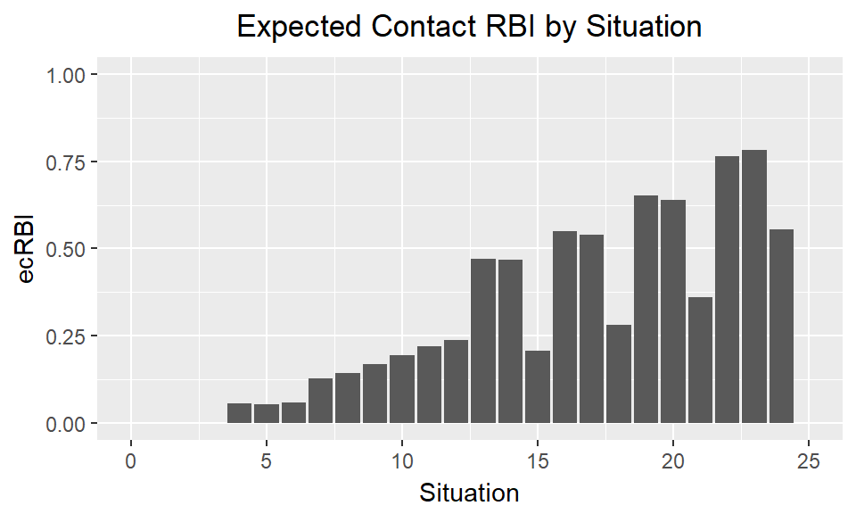

```r
Run_matrix %>%
  ggplot(aes(x = situation, y=ecRBI)) +
  geom_bar(stat = "identity", position = "stack", width = 0.9)+
  xlim(0, 25) + ylim(0,1) +
  labs(x = "Situation", y = "ecRBI", title = "Expected Contact RBI by Situation") +
  theme(plot.title = element_text(hjust = 0.5))
```

### **Other Visualizations**

First things first, I’d like to look at the top 10 batters for this stat in 2017.

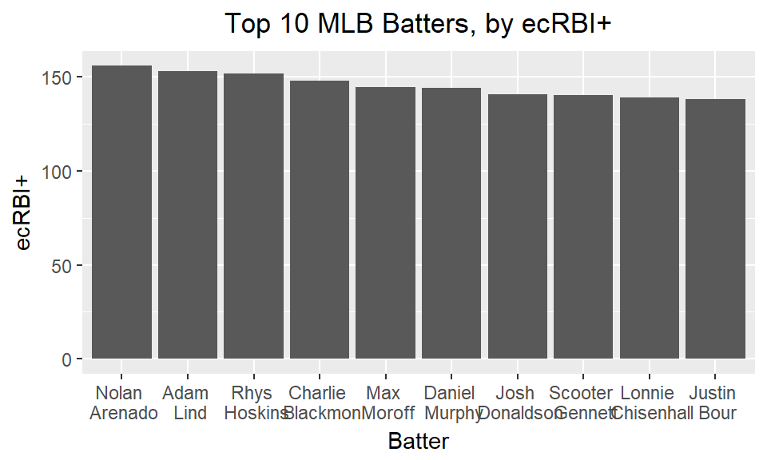

```r
Final %>%
  head(10) %>%
  ggplot(aes(x=reorder(name, -ecRBI_plus), y=ecRBI_plus)) +
  geom_bar(stat = 'identity', position = 'stack', width = 0.9) +
  labs(x = "Batter", y = "ecRBI+", title = "Top 10 MLB Batters, by ecRBI+") +
  theme(plot.title = element_text(hjust = 0.5))
```

The only real surprise here is Max Moroff. The other hitters are widely recognized as very good hitters and we’d expect to see them at the top of the list. Moroff, on the other hand, hit .200 in 2017, an abysmal mark for a position player. However, it seems that Moroff was very good with runners on, as evidenced by his 18 cRBI over only 140 plate appearances.

Another thing I’d like to look at is the worst 10 batters for this stat in 2017.

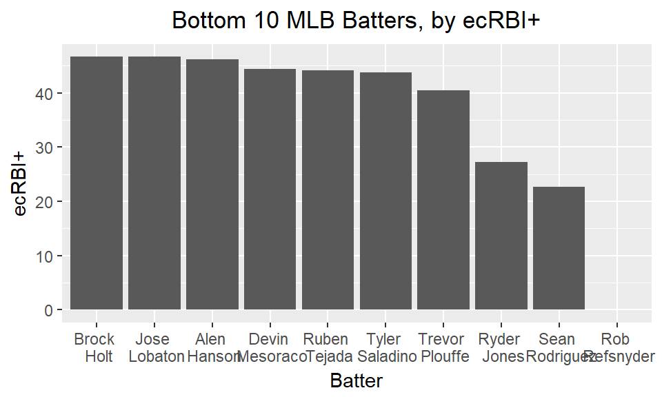

```r
Final %>%
  tail(10) %>%
  ggplot(aes(x=reorder(name, -ecRBI_plus), y=ecRBI_plus)) +
  geom_bar(stat = 'identity', position = 'stack', width = 0.9) +
  labs(x = "Batter", y = "ecRBI+", title = "Bottom 10 MLB Batters, by ecRBI+") +
  theme(plot.title = element_text(hjust = 0.5))
```

These are some of the worst batters in baseball, and this new stat doesn’t disagree.

How does a team of the best players in baseball line up?

This may be a bit subjective, but I’ll be selecting:

- Gary Sanchez, C, NYY
- Paul Goldschmidt, 1B, ARI
- Jose Altuve, 2B, HOU
- Corey Seager, SS, LAD
- Nolan Arenado, 3B, COL
- Justin Upton, LF, LAA
- Charlie Blackmon, CF, COL
- Giancarlo Stanton, RF, MIA

We’ll pretend this is an NL team and that the pitcher can’t hit at all.

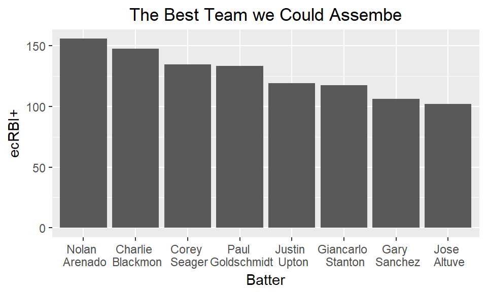

```r
Final %>%
  filter(name == "Gary \n Sanchez" |
         name == "Paul \n Goldschmidt" |
         name == "Jose \n Altuve" |
         name == "Corey \n Seager" |
         name == "Nolan \n Arenado" |
         name == "Justin \n Upton" |
         name == "Charlie \n Blackmon" |
         name == "Giancarlo \n Stanton") %>%
  ggplot(aes(x=reorder(name, -ecRBI_plus), y=ecRBI_plus)) +
  geom_bar(stat = 'identity', position = 'stack', width = 0.9) +
  labs(x = "Batter", y = "ecRBI+", title = "The Best Team we Could Assembe") +
  theme(plot.title = element_text(hjust = 0.5))
```

Something really interesting to note here is that Giancarlo Stanton and Jose Altuve, the NL and AL MVP, respectively, rank rather low as compared to some of the other batters on this list.

And now, something that could be very enlightening. Here I’m going to facet the batters by position and see how the positions stack up against each other.

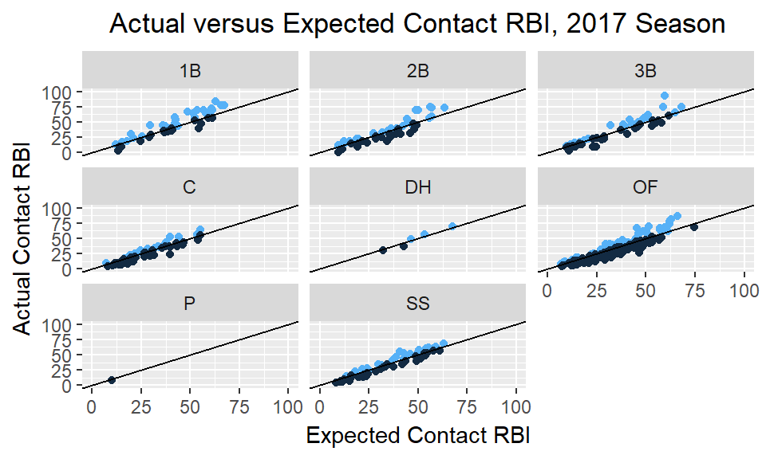

```r
Final %>%
  filter(position != "C " & position != "LF") %>%
  mutate(good_flag = ifelse(ecRBI_plus >= 100, 1, 0)) %>%
  ggplot(aes(x=total_ecRBI, y=total_cRBI, color = good_flag)) +
    geom_point() + geom_abline(slope = 1, intercept = 0) +
    facet_wrap(~position) +
    labs(x="Expected Contact RBI",
         y="Actual Contact RBI",
         title = "Actual versus Expected Contact RBI, 2017 Season") +
  xlim(0, 100) + ylim(0, 100) +
  theme(legend.position = "none", plot.title = element_text(hjust = 0.5))
```

### **Conclusions**

Without further testing, not much can really be said in terms of the predictive power of ecRBI+. It does line up good hitters well at the top end of the spectrum, but it remains to be seen whether that alignment is better than a more standard metric like OPS. Regardless of the feasibility of ecRBI+ as a stat, this analysis has made it very simple to create a new stat, and tweaking it should be very simple.